```python
# Load in necessary packages
import numpy as np
import numpy.random as npr
import pandas as pd
from pandas import DataFrame, Series
import seaborn as sns
import matplotlib.pyplot as plt
import scipy.stats as stats
import statsmodels.api as sm
from sklearn.model_selection import train_test_split
from sklearn.metrics import mean_squared_error
from sklearn.ensemble import RandomForestRegressor
from sklearn.cluster import KMeans
from sklearn.cluster import AgglomerativeClustering
from sklearn.metrics import silhouette_score
import matplotlib.pyplot as plt
```

Q1.

(a) Load the male_stud.csv dataset into Python as a pandas DataFrame.

```python
male = pd.read_csv('/Users/qianqianmeng/Desktop/STAT40800 Final project/'  + 'male_stud.csv')
male.head()
```

|  | large_family | lives_in_city | traveltime | studytime | failures | paid | activities | internet | romantic | famrel | freetime | goout | absences | final_grade |
| --- | --- | --- | --- | --- | --- | --- | --- | --- | --- | --- | --- | --- | --- | --- |
| 0 | 0 | 1 | 1 | 2 | 0 | 1 | 1 | 1 | 0 | 5 | 4 | 2 | 10 | 15 |
| 1 | 0 | 1 | 1 | 2 | 0 | 0 | 0 | 1 | 0 | 4 | 4 | 4 | 0 | 11 |
| 2 | 0 | 1 | 1 | 2 | 0 | 1 | 0 | 1 | 0 | 4 | 2 | 2 | 0 | 19 |
| 3 | 1 | 1 | 1 | 2 | 0 | 1 | 1 | 1 | 0 | 5 | 5 | 1 | 0 | 15 |
| 4 | 0 | 1 | 1 | 1 | 0 | 1 | 1 | 1 | 0 | 4 | 3 | 3 | 2 | 14 |

(b) Inspect the data. How many students are included in this dataset? How many diffrent indicators are included? Does this dataset contain any missing values?

```python
print(f'Number of students are included in this dataset: {len(male)}\n')

num_indicators = len(male.columns) - 1 #final_grade is not indictors
print(f'Number of indicators are included in this dataset: {num_indicators}\n')

if male.isna().any().any() == False:
    print("This dataset does not contain any missing values.\n")
else:
    print("This dataset contains missing values.\n")
```

```
Number of students are included in this dataset: 187

Number of indicators are included in this dataset: 13

This dataset does not contain any missing values.
```

(c) Perform an exploratory data analysis, creating both numerical and graphical summaries of the data. Discuss and interpret your results.

```python
male.astype('object').describe()#calculate categorical descriptive statistics for all variables
```

|  | large_family | lives_in_city | traveltime | studytime | failures | paid | activities | internet | romantic | famrel | freetime | goout | absences | final_grade |
| --- | --- | --- | --- | --- | --- | --- | --- | --- | --- | --- | --- | --- | --- | --- |
| count | 187 | 187 | 187 | 187 | 187 | 187 | 187 | 187 | 187 | 187 | 187 | 187 | 187 | 187 |
| unique | 2 | 2 | 4 | 4 | 4 | 2 | 2 | 2 | 2 | 5 | 5 | 5 | 23 | 17 |
| top | 1 | 1 | 1 | 2 | 0 | 0 | 1 | 1 | 0 | 4 | 3 | 3 | 0 | 10 |
| freq | 125 | 143 | 118 | 85 | 144 | 114 | 105 | 159 | 134 | 88 | 64 | 60 | 52 | 26 |

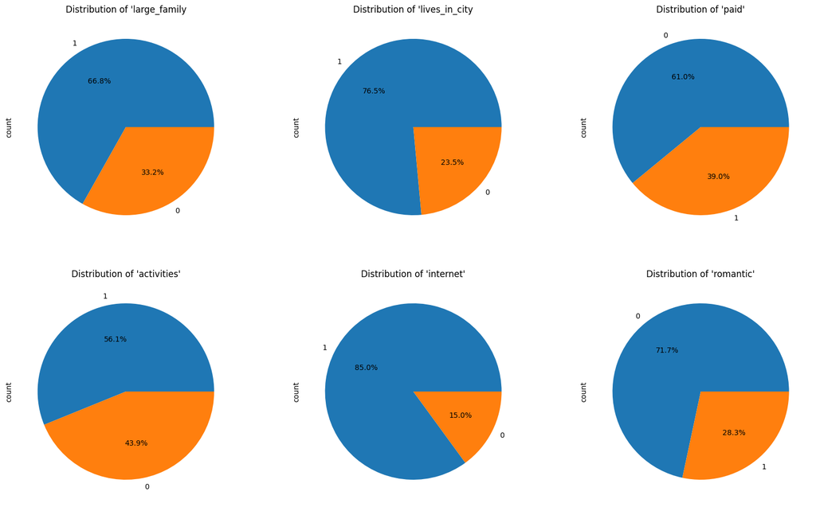

```python
fig = plt.figure(figsize=(20,12))
plt.subplot(2, 3, 1)
male.large_family.value_counts().plot(kind ='pie', autopct='%1.1f%%')
plt.title("Distribution of 'large_family")


plt.subplot(2, 3, 2)
male['lives_in_city'].value_counts().plot.pie(autopct='%1.1f%%')
plt.title("Distribution of 'lives_in_city")


plt.subplot(2, 3, 3)
male['paid'].value_counts().plot.pie(autopct='%1.1f%%')
plt.title("Distribution of 'paid'")


plt.subplot(2, 3, 4)
male['activities'].value_counts().plot.pie(autopct='%1.1f%%')
plt.title("Distribution of 'activities'")

plt.subplot(2, 3, 5)
male.internet.value_counts().plot(kind ='pie', autopct='%1.1f%%')
plt.title("Distribution of 'internet'")

plt.subplot(2, 3, 6)
male.romantic.value_counts().plot(kind ='pie', autopct='%1.1f%%')
plt.title("Distribution of 'romantic'")
```

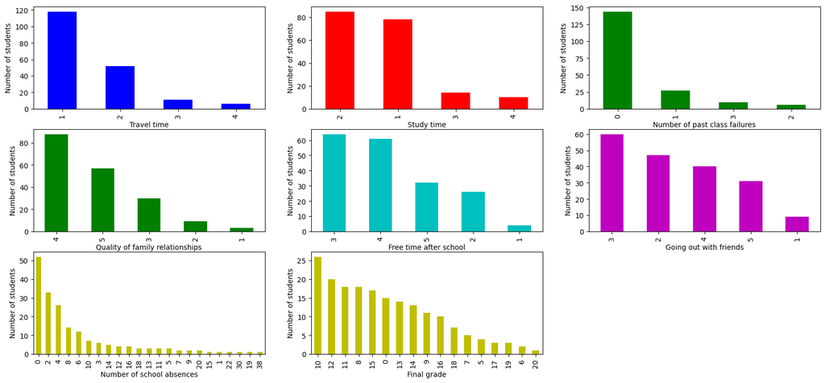

```python
fig = plt.figure(figsize=(20,12))
plt.subplot(4, 3, 1)
male.traveltime.value_counts().plot(kind ='bar',color='b')
plt.xlabel('Travel time')
plt.ylabel('Number of students')


plt.subplot(4, 3, 2)
male.studytime.value_counts().plot(kind ='bar',color='r')
plt.xlabel('Study time')
plt.ylabel('Number of students')


plt.subplot(4, 3, 3)
male.failures.value_counts().plot(kind ='bar',color='g')
plt.xlabel('Number of past class failures')
plt.ylabel('Number of students')

plt.subplot(4, 3, 4)
male.famrel.value_counts().plot(kind ='bar',color='g')
plt.xlabel('Quality of family relationships')
plt.ylabel('Number of students')

plt.subplot(4, 3, 5)
male.freetime.value_counts().plot(kind ='bar',color='c')
plt.xlabel('Free time after school')
plt.ylabel('Number of students')

plt.subplot(4, 3, 6)
male.goout.value_counts().plot(kind ='bar',color='m')
plt.xlabel('Going out with friends')
plt.ylabel('Number of students')

plt.subplot(4, 3, 7)
male.absences.value_counts().plot(kind ='bar',color='y')
plt.xlabel('Number of school absences')
plt.ylabel('Number of students')

plt.subplot(4, 3, 8)
male.final_grade.value_counts().plot(kind ='bar',color='y')
plt.xlabel('Final grade')
plt.ylabel('Number of students')
```

Note that 'large_family', 'lives_in_city', 'paid', 'activities', 'internet', and 'romantic' each have only two unique values; they are binary: yes or no.

'large_family': A majority of the students (125 out of 187: 66.8%) come from large families. 'lives_in_city': Most students (143 out of 187: 76.5%) live in the city. 'paid': Most students (114 out of 187: 61%) have not taken any extra paid math classes. 'activities': 105 (56.1%) students are involved in extra-curricular activities. 'internet': A significant majority (159 out of 187: 85%) have access to the internet at home. 'romantic': The majority (134 out of 187: 71.7%) are not in romantic relationships.

Q2

(a) Load the female_stud.csv dataset into Python as a pandas DataFrame

```python
female = pd.read_csv('/Users/qianqianmeng/Desktop/STAT40800 Final project/'  + 'female_stud.csv')

female.tail()
```

|  | large_family | lives_in_city | traveltime | studytime | failures | paid | activities | internet | romantic | famrel | freetime | goout | absences | final_grade |
| --- | --- | --- | --- | --- | --- | --- | --- | --- | --- | --- | --- | --- | --- | --- |
| 203 | 1 | 0 | 2 | 3 | 0 | 1 | 0 | 0 | 0 | 5 | 3 | 3 | 2 | 10 |
| 204 | 1 | 0 | 3 | 1 | 0 | 1 | 1 | 1 | 1 | 4 | 4 | 3 | 7 | 6 |
| 205 | 1 | 0 | 1 | 3 | 1 | 0 | 1 | 1 | 0 | 5 | 4 | 2 | 0 | 0 |
| 206 | 0 | 1 | 1 | 2 | 0 | 1 | 0 | 1 | 0 | 4 | 3 | 4 | 0 | 8 |
| 207 | 1 | 1 | 2 | 2 | 1 | 0 | 1 | 0 | 0 | 1 | 1 | 1 | 0 | 0 |

(b) Inspect the data. How many students are included in this dataset? Are the indicators the same as those in the male group?

```python
print(f'Number of students are included in this dataset: {len(female)}\n')

num_indicators = len(female.columns) - 1 #final_grade is is the outcome not indictors
print(f'Number of indicators are included in this dataset: {num_indicators}\n')

male.columns==female.columns
```

```
Number of students are included in this dataset: 208

Number of indicators are included in this dataset: 13
```

```
array([ True,  True,  True,  True,  True,  True,  True,  True,  True,
        True,  True,  True,  True,  True])
```

Yes, the indicators the same as those in the male group.

(c) Perform a t-test, for each of the measurements, to test whether any of the indicators differ between the male and the female groups. Use a significance level of α = 0.01. Display the t-score and p-value for each measurement. Clearly state the conclusion of your tests and explain your reasoning.

```python
male_with_indicators = male.drop(['final_grade'],axis=1)
female_with_indicators = female.drop(['final_grade'],axis=1)

t_statistic, p_value = stats.ttest_ind(male_with_indicators, female_with_indicators)
t_statistic, p_value

# convert column names to a list
indicators = list(male_with_indicators.columns)
indicators = np.array(indicators) # Convert the list to a NumPy array

t_test_summa = pd.DataFrame({'indicators': indicators, 't_statistic': t_statistic, 'p_value': p_value})
print(t_test_summa)

alpha = 0.01

# Iterate over rows using iloc
for i in range(len(t_test_summa)):
    if t_test_summa.iloc[i]['p_value'] < alpha:
        measurement = t_test_summa.iloc[i]['indicators']
        print(f'Reject the null hypothesis, and conclude there is a significant difference between male and female groups in measurement: {measurement}\n')
```

```
       indicators  t_statistic       p_value
0    large_family    -1.788677  7.443690e-02
1   lives_in_city    -0.565304  5.721898e-01
2      traveltime     1.186055  2.363171e-01
3       studytime    -6.378011  5.045044e-10
4        failures     0.881778  3.784358e-01
5            paid    -2.581427  1.020069e-02
6      activities     1.989053  4.738832e-02
7        internet     0.875356  3.819147e-01
8        romantic    -2.033136  4.271032e-02
9          famrel     1.171091  2.422716e-01
10       freetime     4.873860  1.590705e-06
11          goout     1.508960  1.321126e-01
12       absences    -1.330451  1.841411e-01
Reject the null hypothesis, and conclude there is a significant difference between male and female groups in measurement: studytime

Reject the null hypothesis, and conclude there is a significant difference between male and female groups in measurement: freetime
```

Reason: A p-value smaller than 0.01 indicates that we reject the null hypothesis (H0), which posits that the indicators are the same in the male and female groups. Consequently, we conclude that there are differences between these groups.Q3

(a) Combine the two datasets into a single DataFrame.

```python
combined_data = pd.concat([male, female]) #stack all the male entries on top of the female entries, since they have same variables
combined_data.info() #check, now 395 rows
```

```
<class 'pandas.core.frame.DataFrame'>
Index: 395 entries, 0 to 207
Data columns (total 14 columns):
 #   Column         Non-Null Count  Dtype
---  ------         --------------  -----
 0   large_family   395 non-null    int64
 1   lives_in_city  395 non-null    int64
 2   traveltime     395 non-null    int64
 3   studytime      395 non-null    int64
 4   failures       395 non-null    int64
 5   paid           395 non-null    int64
 6   activities     395 non-null    int64
 7   internet       395 non-null    int64
 8   romantic       395 non-null    int64
 9   famrel         395 non-null    int64
 10  freetime       395 non-null    int64
 11  goout          395 non-null    int64
 12  absences       395 non-null    int64
 13  final_grade    395 non-null    int64
dtypes: int64(14)
memory usage: 46.3 KB
```

(b) Compute the Pearson correlation coefficient between each of the measurements and identify which indicators are most correlated. List the four most strongly correlated pairs.

```python
#as clarified in the Discussion board "All the columns have to be included", so I did not drop 'final_grade'.

correlation_matrix = combined_data.corr().abs()#there is positive correlation and negative correlation, use absolute value to find the most correlated

#unstack the correlation_matrix, and then sort in descending order
sorted_pairs = correlation_matrix.unstack().sort_values(kind="quicksort", ascending=False)

# Remove self-correlations
sorted_pairs.drop_duplicates().head(5)
```

```
large_family   large_family     1.000000
final_grade    failures         0.360415
traveltime     lives_in_city    0.328096
goout          freetime         0.285019
lives_in_city  internet         0.216842
dtype: float64
```

```python
#I also found the following code online, which we haven't learned yet, but I think it is neater.
#https://stackoverflow.com/questions/17778394/list-highest-correlation-pairs-from-a-large-correlation-matrix-in-pandas

correlation_matrix = combined_data.corr().abs()

#extract upper triangle matrix without diagonal (k = 1)
sol = (correlation_matrix.where(np.triu(np.ones(correlation_matrix.shape), k=1).astype(bool))
                  .stack()
                  .sort_values(ascending=False))

print("The four most strongly correlated pairs are :")
print(sol.head(4))
```

```
The four most strongly correlated pairs are :
failures       final_grade    0.360415
lives_in_city  traveltime     0.328096
freetime       goout          0.285019
lives_in_city  internet       0.216842
dtype: float64
```

(c) Create scatter plots for the each of the correlated pairs identified in Q3(b). Are the relationships as expected from the correlation coefficients? The full dataset should be used for all subsequent questions.

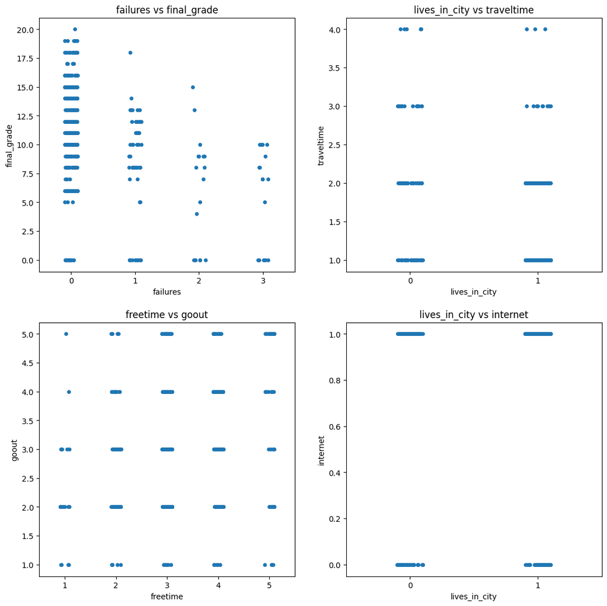

```python
#A stripplot is a type of scatter plot
# Scatter Plot with Jitter, 'jitter=True' avoiding overlapping

fig, axes = plt.subplots(2, 2, figsize=(13, 13))

sns.stripplot(x="failures", y="final_grade", data=combined_data, jitter=True, ax=axes[0, 0])
axes[0, 0].set_title("failures vs final_grade")


sns.stripplot(x="lives_in_city", y="traveltime", data=combined_data, jitter=True, ax=axes[0, 1])
axes[0, 1].set_title("lives_in_city vs traveltime")


sns.stripplot(x="freetime", y="goout", data=combined_data, jitter=True, ax=axes[1, 0])
axes[1, 0].set_title("freetime vs goout")


sns.stripplot(x="lives_in_city", y="internet", data=combined_data, jitter=True, ax=axes[1, 1])
axes[1, 1].set_title("lives_in_city vs internet")

plt.show()
```

Q4

(a) In the Portuguese system a grade from 0 to 9.5 is considered as a FAIL, while grades from 10 to 20 are considered PASS. Create a new column in the dataframe indicating whether the student passed or failed. Use this column as dependent variable for the regression task in the following items (Remaining indicators except for the final grade have to be used as predictor variables).

```python
bins = [-1, 9.5, 20] #(-1, 9.5] (9.5, 20]
labels = ["FAIL","PASS"]
combined_data['status'] = pd.cut(combined_data['final_grade'], bins=bins, labels=labels)

combined_data.status.unique() #check
```

```
['PASS', 'FAIL']
Categories (2, object): ['FAIL' < 'PASS']
```

(b) Separate the data into response and predictor variables and standardise the predictor variables.

```python
X =combined_data.drop(['final_grade','status'], axis=1) #predictor varibles
X_std = (X-X.mean())/X.std() #standardise
y = combined_data['status'].map({'PASS': 1, 'FAIL': 0}) #Change 'status' column to 1 and 0s
```

(c) Fit a logistic regression model and interpret the fitted model.

```python
X_std.insert(0,'intercept',1) # Adding intercept columns

logit_model = sm.Logit(y, X_std).fit()
print(logit_model.summary())
```

```
Optimization terminated successfully.
         Current function value: 0.556201
         Iterations 5
                           Logit Regression Results
==============================================================================
Dep. Variable:                 status   No. Observations:                  395
Model:                          Logit   Df Residuals:                      381
Method:                           MLE   Df Model:                           13
Date:                Fri, 16 Feb 2024   Pseudo R-squ.:                  0.1221
Time:                        10:30:22   Log-Likelihood:                -219.70
converged:                       True   LL-Null:                       -250.25
Covariance Type:            nonrobust   LLR p-value:                 3.330e-08
=================================================================================
                    coef    std err          z      P>|z|      [0.025      0.975]
---------------------------------------------------------------------------------
intercept         0.7801      0.118      6.602      0.000       0.548       1.012
large_family     -0.1204      0.121     -0.998      0.318      -0.357       0.116
lives_in_city     0.0507      0.125      0.404      0.686      -0.195       0.297
traveltime        0.0063      0.126      0.050      0.960      -0.241       0.254
studytime         0.0400      0.125      0.320      0.749      -0.205       0.285
failures         -0.6692      0.130     -5.132      0.000      -0.925      -0.414
paid              0.0768      0.121      0.633      0.527      -0.161       0.315
activities       -0.0269      0.119     -0.226      0.821      -0.260       0.206
internet          0.1361      0.119      1.147      0.251      -0.096       0.369
romantic         -0.1623      0.117     -1.383      0.167      -0.392       0.068
famrel            0.0644      0.118      0.547      0.584      -0.166       0.295
freetime          0.1361      0.126      1.079      0.280      -0.111       0.383
goout            -0.4254      0.127     -3.344      0.001      -0.675      -0.176
absences         -0.1279      0.111     -1.149      0.250      -0.346       0.090
=================================================================================
```

Interpretation: This fitted model suggests that the 'intercept' and the predictors 'failures' and 'goout' are statistically significant for predicting 'status', as their p-values are less than 0.05. Other variables, although included in the model, do not show a statistically significant association based on their p-values.

(d) Perform forward selection for your regression model using the Akaike Information Criterion (AIC). Examine the selected model and discuss your findings in relation to the model fitted in part (b).

```python
#reference: https://datascience.stackexchange.com/questions/937/does-scikit-learn-have-a-forward-selection-stepwise-regression-algorithm

#look at the shapes of both
print(X_std.shape)
print(y.shape)

#verbose=True, the function prints details of the feature selection process.
def stepwise_selection_by_AIC_logistic(X, y, verbose=True):
    included = [] #store variables
#Initiates an infinite loop for the feature selection process, which will stop when no more features can be added to reduce AIC.
    while True:
        changed = False
        excluded = list(set(X.columns) - set(included)) #indicators haven't selected yet
        new_aic = pd.Series(index=excluded)

        # Add each variable one by one and calculate the AIC for logistic regression
        for new_column in excluded:
            model = sm.Logit(y, sm.add_constant(pd.DataFrame(X[included + [new_column]]))).fit(disp=0)
            new_aic[new_column] = model.aic

        # Find the variable that decreases the AIC the most
        best_aic = new_aic.min()
        current_model_aic = sm.Logit(y, sm.add_constant(pd.DataFrame(X[included]))).fit(disp=0).aic if included else float('inf')
        if best_aic < current_model_aic:
            best_feature = new_aic.idxmin()
            included.append(best_feature)
            changed = True
            if verbose:
                print('Add  {:30} with AIC {:.6}'.format(best_feature, best_aic))

        if not changed:
            break

    return included

print('Final model variables:')
print(stepwise_selection_by_AIC_logistic(X_std,y))
```

```
(395, 14)
(395,)
Final model variables:
Add  failures                       with AIC 461.12
Add  goout                          with AIC 453.807
['failures', 'goout']
```

The selected model using AIC includes only the predictors 'failures' and 'goout', which exactly aligns with the suggestions of the fitted model in part (b).

Q5

(a) Split the data into appropriate training and test sets.

```python
X_original =combined_data.drop(['final_grade','status'], axis=1)
y_original = combined_data['final_grade']

train_size = 296 #395 observations, get 75%
np.random.seed(123)
train_select = np.random.permutation(len(y_original))


X_train = X_original.iloc[train_select[:train_size]].reset_index(drop=True)
X_test = X_original.iloc[train_select[train_size:]].reset_index(drop=True)
y_train = y_original.iloc[train_select[:train_size]].reset_index(drop=True)
y_test = y_original.iloc[train_select[train_size:]].reset_index(drop=True)

print(X_train.shape)#check
print(y_train.shape)
```

```
(296, 13)
(296,)
```

(b) Fit a random forest regression model with 10 trees using the training data. Include the argument random_state=101 in the random forest regression function to ensure reproducible results. Determine which variables are most important in predicting the final grade of a student. Discuss your findings in relation to the logistic models fit in question 4.

```python
rf = RandomForestRegressor(n_estimators=10, random_state=101)
rf.fit(X_train, y_train)

importances = rf.feature_importances_
variables = rf.feature_names_in_

df = pd.DataFrame({'variables ': variables, 'importances': importances})
df.sort_values("importances", ascending=False)
```

|  | variables | importances |
| --- | --- | --- |
| 12 | absences | 0.224958 |
| 4 | failures | 0.129695 |
| 11 | goout | 0.101143 |
| 3 | studytime | 0.081641 |
| 2 | traveltime | 0.080273 |
| 9 | famrel | 0.075819 |
| 10 | freetime | 0.066930 |
| 5 | paid | 0.047969 |
| 8 | romantic | 0.044868 |
| 7 | internet | 0.039740 |
| 1 | lives_in_city | 0.039234 |
| 6 | activities | 0.037251 |
| 0 | large_family | 0.030479 |

From the above chart, we understand that fitting a random forest regression model with 10 trees revealed that the most important variables for predicting a student's final grade are 'absences', 'failures', and 'goout'. 'Failures' and 'goout' were previously identified as key predictors in question 4.

Logistic regression, though similar to standard linear regression in its use of binary response variables treated as Bernoulli-distributed, differs significantly from random forest, which is a non-linear model capable of capturing more complex relationships between variables. This distinction can lead to different variables being identified as important. Furthermore, random forests can naturally account for interactions between variables without explicitly specifying them. The choice of model can influence the interpretation of which features are most important in predicting an outcome.

(c) Use the random forest regression model to predict the final grade of a student for the test set. Create a scatter plot of the true final grade versus the predicted one. Interpret your plot.

```
19.732020202020202
```

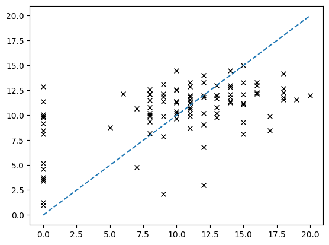

```python
# Make predictions on the test set
rf_test_pred = rf.predict(X_test)
fig = plt.figure()
plt.plot(y_test,rf_test_pred,'kx')
plt.plot([0,20], [0,20], ls="--")

RSS_rf = np.mean(pow((rf_test_pred- y_test),2))
print(RSS_rf)
```

(d) Assess the performance of a random forest regression model with 5, 10, 50, 100, 500, 1000, and 5000 trees in predicting the nal grade of a student. You should repeat the model fitand prediction 20 times for each number of trees, using a different random state for each repeat. Create a plot of the model performance as a function of the number of trees (use a log axis for the number of trees). The plot should show the mean and standard error of the performance metric for each number of trees. Discuss your findings.

```python
# a list of number of trees given
num_trees_list = [5, 10, 50, 100, 500, 1000, 5000]

mse_mean_list = []
mse_std_list = []

plt.figure(figsize=(9, 7))

for num_trees in num_trees_list:
    mse_scores = []

    for _ in range(20):
        rf = RandomForestRegressor(n_estimators=num_trees) #by default, random_state=none wiill give different random state for each repeat
        rf.fit(X_train, y_train)

        y_pred = rf.predict(X_test)

        # Compute mean squared error MSE
        mse = mean_squared_error(y_test, y_pred)
        mse_scores.append(mse)
    # Calculate mean and standard deviation of MSE for the current number of trees
    mse_mean = np.mean(mse_scores)
    mse_std = np.std(mse_scores)

    mse_mean_list.append(mse_mean)
    mse_std_list.append(mse_std)


plt.errorbar(num_trees_list, mse_mean_list, yerr=mse_std_list, fmt='o-', label='MSE')
plt.xlabel('Number of Trees')
plt.ylabel('Mean Squared Error (MSE)')
plt.xscale('log')#log axis
plt.title('Random Forest Regression Performance vs. Number of Trees')
plt.legend()
plt.show()
```

[output not shown]

(e) Explain the rationale for fiting the model multiple times with different random states.

Fitting a Random Forest regression model multiple times with different random states is crucial for ensuring its robustness and reliability. By varying random states, the model's selection of features and data points for each tree is randomized, which better assesses its performance on unseen data. This approach highlights how randomness in data sampling and feature selection impacts the model's effectiveness. It ensures consistency in the model's predictions, aids in fine-tuning parameters, checks for overfitting, and guarantees reproducibility. Ultimately, this practice offers a clearer insight into the model's potential performance in real-world scenarios, marking it as an essential step in model validation.

Q6

(a) Perform a k-means cluster analysis, using the indicators as the features. Run the clustering algorithm for dierent numbers of clusters (integers from 1 to 10). Plot the model performance as a function of the number of clusters and identify the optimal number of clusters for this data.

```python
combined_data.head()
original_data = combined_data.drop('status', axis=1) #get the traget data

original_data.head()
```

```python
def optimise_k_means(data, max_k):
    means = []
    inertias = []
    for k in range(1, max_k):
        model = KMeans(k)
        model.fit(X_original)
        means.append(k)
        inertias.append(model.inertia_)
    plt.plot(means, inertias, marker='o', linestyle='--')
    plt.title('Elbow Method to Determine Optimal Number of Clusters')
    plt.xlabel('Number of clusters')
    plt.ylabel('Inertias')
    plt.grid(True)


optimise_k_means(original_data, 11)
```

[output not shown]

(b) Perform a k-means cluster analysis, using the optimal number of clusters (identified in part (a)), and identify the most discriminatory variables. (Hint: Create histograms for each variable, with the data separated by cluster.)

```python
model = KMeans(n_clusters=4)
model.fit(original_data)
#predict the labels of clusters
pre = model.predict(original_data)

# add 'cluster' labels to the data
original_data['cluster'] = pre

# Iterate over all the features, except the last 'cluster' column
for i in range(original_data.shape[1] - 1):
    col_name = original_data.columns[i]  # Get the each variable name
    clusters = original_data['cluster'].unique()  # unique clusters

    # Set the figure size
    plt.figure(figsize=(10, 5))

    #sort clusters in order
    for cluster in sorted(clusters):

        # get the data for each cluster of each variable
        cluster_data = original_data[original_data['cluster'] == cluster]

        plt.hist(cluster_data[col_name], bins='auto', alpha=0.5, label=f'cluster {cluster}')

    plt.title(f'Histogram of {col_name} by cluster')
    plt.xlabel(col_name)
    plt.ylabel('Freq')
    plt.legend()
    plt.show()
```

[output not shown]

c) Create a series of scatter plots for the most discriminatory variables, colouring the points by cluster number. Discuss your ndings. Do your findings support the claim that multiple categories of students, with distinctly dierent characteristics, are included in this dataset?

```python
# clusters = original_data['cluster'].unique()

columns = ['goout', 'studytime', 'famrel']

for column in columns:
    plt.figure(figsize=(9, 7))


    sns.stripplot(x=column, y='absences', hue='cluster', data=original_data, jitter=True)

    plt.title(f'{column} vs Absences by Cluster')
    plt.xlabel(column)
    plt.ylabel('absences')
    plt.legend(title='Cluster')
    plt.show()
```

[output not shown]

```python
columns = ['studytime', 'famrel']

for column in columns:
    plt.figure(figsize=(9, 7))


    sns.stripplot(x=column, y='goout', hue='cluster', data=original_data, jitter=True)

    plt.title(f'{column} vs Goout by Cluster')
    plt.xlabel(column)
    plt.ylabel('goout')
    plt.legend(title='Cluster')
    plt.show()
```

[output not shown]

```python
columns = ['famrel']

for column in columns:
    plt.figure(figsize=(9, 7))

    sns.stripplot(x=column, y='studytime', hue='cluster', data=original_data, jitter=True)

    plt.title(f'{column} vs Freetime by Cluster')
    plt.xlabel(column)
    plt.ylabel('studytime')
    plt.legend(title='Cluster')
    plt.show()
```

[output not shown]

(d) I picked agglomerative clustering, in this algorithm, each data point is initially treated as a separate cluster, and then the algorithm iteratively merges the closest pairs of clusters until all data points are assigned to a single cluster. Hierarchical clustering is a powerful technique for grouping similar data points into clusters based on their similarities or dissimilarities. It's also works well for datasets where the inherent structure is hierarchical.

```python
original_2 = original_data.drop('cluster', axis=1) #get the traget data

npr.seed(123)
n=25
ind = np.random.permutation(len(original_2))
sub = original_data.iloc[ind[:n]]
labels = original_data['final_grade'].iloc[ind[:n]]

print(sub.shape)
print(labels.shape)#same number of rows


import scipy
from scipy.cluster.hierarchy import linkage, dendrogram
mergings = linkage(sub, method='complete')
dendrogram(mergings)
plt.axhline(y=25, color='black', linestyle='--')
plt.show()
```

[output not shown]

```python
###alternative way is to use Silhouette Scores###
def optimise_agglomerative_clustering(data, max_k):
    silhouette_scores = []
    means = []
    for k in range(2, max_k):  # silhouette score isn't defined for k=1
        model = AgglomerativeClustering(n_clusters=k,linkage='complete')
        labels = model.fit_predict(data)
        silhouette_scores.append(silhouette_score(data, labels))
        means.append(k)

    plt.plot(means, silhouette_scores, marker='o', linestyle='--')
    plt.title('Silhouette Scores to Determine Optimal Number of Clusters')
    plt.xlabel('Number of clusters')
    plt.ylabel('Silhouette Score')
    plt.grid(True)
    plt.show()
optimise_agglomerative_clustering(original_2, 11)
```

[output not shown]

```python
model1 = AgglomerativeClustering(n_clusters=2)
original_2['cluster'] = model1.fit_predict(original_2)

# Iterate over all the features, except the last 'cluster' column
for i in range(original_2.shape[1] - 1):
    col_name = original_2.columns[i]  # Get the each variable name
    clusters = original_2['cluster'].unique()  # unique clusters

    # Set the figure size
    plt.figure(figsize=(10, 5))

    #sort clusters in order
    for cluster in sorted(clusters):

        # get the data for each cluster of each variable
        cluster_data = original_2[original_2['cluster'] == cluster]

        plt.hist(cluster_data[col_name], bins='auto', alpha=0.5, label=f'cluster {cluster}')

    plt.title(f'Histogram of {col_name} by cluster')
    plt.xlabel(col_name)
    plt.ylabel('Freq')
    plt.legend()
    plt.show()
```

[output not shown]

(c)

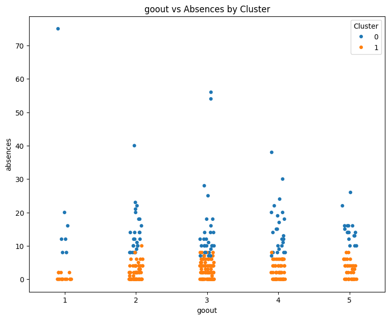

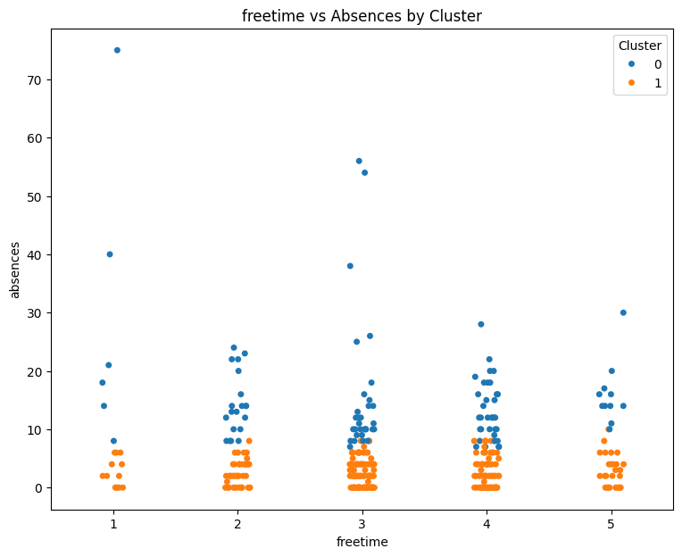

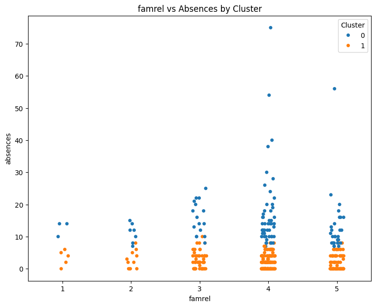

```python
# clusters = original_2['cluster'].unique()

columns = ['goout', 'freetime', 'famrel']

for column in columns:
    plt.figure(figsize=(9, 7))

    sns.stripplot(x=column, y='absences', hue='cluster', data=original_2, jitter=True)

    plt.title(f'{column} vs Absences by Cluster')
    plt.xlabel(column)
    plt.ylabel('absences')
    plt.legend(title='Cluster')
    plt.show()
```

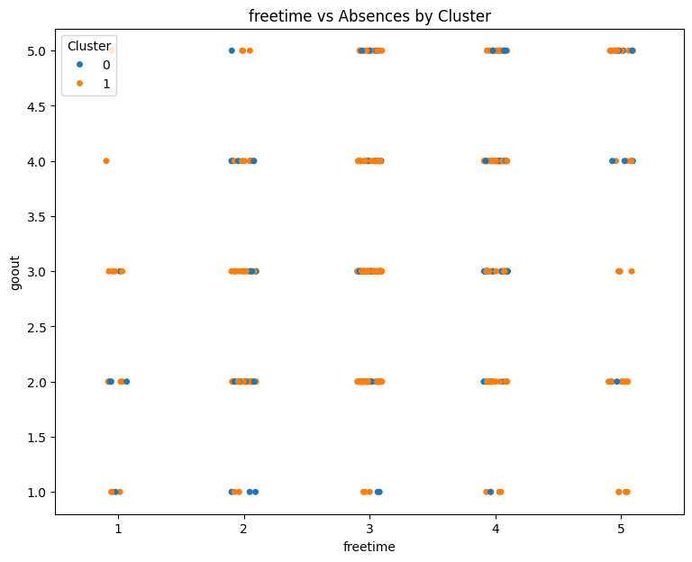

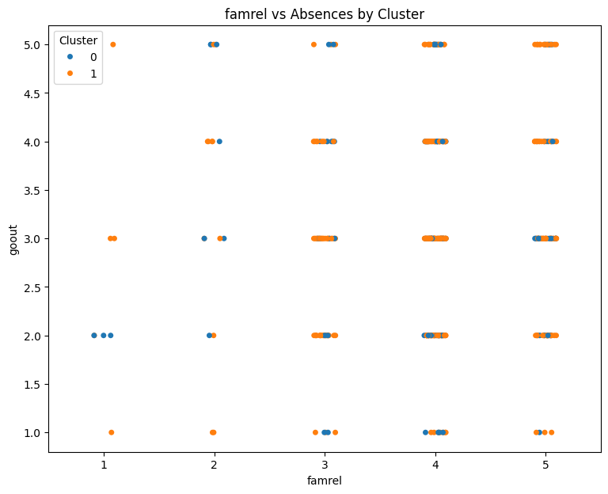

```python
columns = ['freetime', 'famrel']

for column in columns:
    plt.figure(figsize=(9, 7))

    sns.stripplot(x=column, y='goout', hue='cluster', data=original_2, jitter=True)

    plt.title(f'{column} vs Absences by Cluster')
    plt.xlabel(column)
    plt.ylabel('goout')
    plt.legend(title='Cluster')
    plt.show()
```

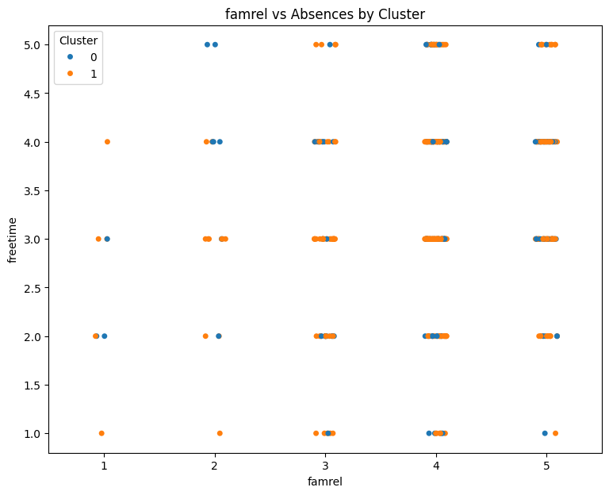

```python
columns = ['famrel']

for column in columns:
    plt.figure(figsize=(9, 7))

    sns.stripplot(x=column, y='freetime', hue='cluster', data=original_2, jitter=True)

    plt.title(f'{column} vs Absences by Cluster')
    plt.xlabel(column)
    plt.ylabel('freetime')
    plt.legend(title='Cluster')
    plt.show()
```

Results: This time, the scatter plot between 'absences' and other variables shows a clear separation of clusters, suggesting that 'absences' might be a significant variable in distinguishing between different categories of students. This variable alone indicates some level of distinct characteristics within the student population. However, the lack of clear separation in scatter plots involving other variables, as seen here and in part (c), suggests that these variables may not be as effective in differentiating between student categories. This could imply that the distinctions between student categories are not uniformly strong across all variables, or that some variables are not relevant in defining these categories.